# Appendix 3: Binomial Example

Understanding mixed effects models through data simulation

Lisa M. DeBruine & Dale J. Barr

## Simulating binomial data with crossed random factors

To give an overview of the simulation task, we will simulate data from a design with crossed random factors of subjects and stimuli, fit a model to the simulated data, and then try to recover the parameter values we put in from the output. In this hypothetical study, subjects classify the emotional expressions of faces as quickly as possible, and we use accuracy (correct/incorrect) as the primary dependent variable. The faces are of two intrinsic types: either from the subject’s ingroup or from an outgroup. For simplicity, we further assume that each face appears only once in the stimulus set. The key question is whether there is any difference in classification accuracy across the type of face.

### Required software

```r
# load required packages
library("lme4")        # model specification / estimation
library("afex")        # anova and deriving p-values from lmer
library("broom.mixed") # extracting data from model fits
library("faux")        # data simulation
# NOTE: to install the 'faux' package, use:
# devtools::install_github("debruine/faux")
library("tidyverse")   # data wrangling and visualisation

# ensure this script returns the same results on each run
set.seed(8675309)
```

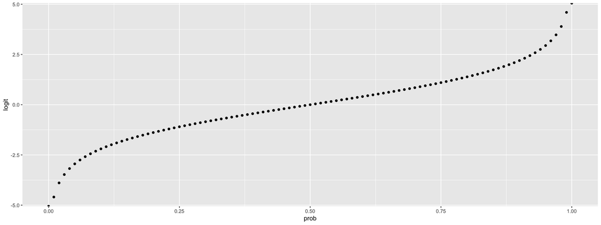

```r
logit <- function(x) { log(x / (1 - x)) }
inv_logit <- function(x) { 1 / (1 + exp(-x)) }

data.frame(
  prob = seq(0,1,.01)
) %>%
  mutate(logit = logit(prob)) %>%
  ggplot(aes(prob, logit)) +
  geom_point()
```

### Data simulation function

The data generating process is slighly different for binomial logistic regression. The random effects and their correlations are set the same way as for a gaussian model (you’ll need some pilot data to estimate reasonable parameters), but we don’t need an error term.

```r
# set up the custom data simulation function
my_bin_data <- function(nsubj  = 100, # number of subjects
                        nitem  = 50,  # number of items
                        b0     = 0, # intercept
                        b1     = 0, # effect of category
                        I0i_sd = 1, # by-item random intercept sd
                        S0s_sd = 1, # by-subject random intercept sd
                        S1s_sd = 1, # by-subject random slope sd
                        scor   = 0 # correlation between intercept and slope
                        ) {
  # simulate items
  items <- faux::sim_design(
    between = list(category = c("ingroup", "outgroup")),
    n = nitem,
    sd = I0i_sd,
    dv = "I0i",
    id = "item_id",
    plot = FALSE
  )

  # effect code category
  items$cat <- recode(items$category, "ingroup" = -0.5, "outgroup" = 0.5)

  # simulate subjects
  subjects <- faux::sim_design(
    within = list(effect = c(S0s = "By-subject random intercepts",
                             S1s = "By-subject random slopes")),
    n = nsubj,
    sd = c(S0s_sd, S1s_sd),
    r = scor,
    id = "subj_id",
    plot = FALSE
  )

  # simulate trials
  dat_sim <- crossing(subj_id = subjects$subj_id,
                      item_id = items$item_id) %>%
    inner_join(subjects, "subj_id") %>%
    inner_join(items, "item_id") %>%
    mutate(Y = b0 + I0i + S0s + (b1 + S1s) * cat,
           pr = inv_logit(Y),
           Y_bin = rbinom(nrow(.), 1, pr)) %>%
  select(subj_id, item_id, category, cat, Y, Y_bin)

  dat_sim
}

# set up the power function
my_glmer_power <- function(...) {
  # ... is a shortcut that forwards any arguments to my_sim_data()
  dat_sim <- my_bin_data(...)
  mod_sim <- glmer(Y_bin ~ 1 + cat + (1 | item_id) + (1 + cat | subj_id),
                data = dat_sim, family = "binomial")

  broom.mixed::tidy(mod_sim)
}
```

```r
# run simulations

prob2param <- function(a = 0, b = 0) {
  list(
    b0 = (logit(a) + logit(b))/2,
    b1 = logit(a) - logit(b)
  )
}

reps <- 5
b = prob2param(.4, .6)
S0s_sd = 1
S1s_sd = 1
I0i_sd = 1
scor = 0.5

sims <- purrr::map_df(1:reps, ~my_glmer_power(b0 = b$b0,
                                             b1 = b$b1,
                                             S0s_sd = S0s_sd,
                                             S1s_sd = S1s_sd,
                                             I0i_sd = I0i_sd,
                                             scor = scor))
```

### Calculate mean estimates and cell probabilities

```r
est <- sims %>%
  group_by(group, term) %>%
  summarise(
    mean_estimate = mean(estimate)
  ) %>% ungroup()


pr0 <- inv_logit(est[[1,3]]) %>% round(2)
pr1_plus <- inv_logit(est[[1,3]] + .5*est[[2,3]]) %>% round(2)
pr1_minus <- inv_logit(est[[1,3]] - .5*est[[2,3]]) %>% round(2)

est %>% mutate(
  sim = c(b$b0, b$b1, I0i_sd, scor, S0s_sd, S1s_sd),
  prob = c(pr0, paste0(pr1_minus, ":", pr1_plus), rep(NA, 4))
) %>%
  mutate_if(is.numeric, round, 2)
```

| group | term | mean_estimate | sim | prob |
| --- | --- | --- | --- | --- |
| NA | (Intercept) | 0.00 | 0.00 | 0.5 |
| NA | cat | -0.82 | -0.81 | 0.6:0.4 |
| item_id | sd__(Intercept) | 1.00 | 1.00 | NA |
| subj_id | cor__(Intercept).cat | 0.49 | 0.50 | NA |
| subj_id | sd__(Intercept) | 1.01 | 1.00 | NA |
| subj_id | sd__cat | 0.96 | 1.00 | NA |

## 2ww*2wb design

In this example, 100 subjects will respond twice (for happy and angry expressions) to 50 items; 25 items in each of 2 categories. In this example, `expression` is a within-subject and within-item factor and `category` is a within-subject and between-item factor.

```r
ext_bin_data <- function(
  nsubj        = 100, # number of subjects/btwn-grp
  nitem        =  25, # number of items/btwn-grp
  b0           =   0, # grand mean
  b_cat        =   0, # main effect of category
  b_exp        =   0, # main effect of expression
  b_cat_exp    =   0, # interaction between category and expression
  I0i_sd       =   1, # by-item random intercept sd
  Iexp_sd      =   1, # by-item random slope for exp
  icor         =   0, # by-item random effect correlation
  S0s_sd       =   1, # by-subject random intercept sd
  Scat_sd      =   1, # by-subject random slope sd for category
  Sexp_sd      =   1, # by-subject random slope sd for exp
  Scat_exp_sd  =   1, # by-subject random slope sd for category*exp
  # by-subject random effect correlations
  scor         = c(0, 0, 0,   # S0s  * cat, exp, tc
                      0, 0,   # cat  *      exp, tc
                         0)  # exp  *           tc
) {

  # simulate items
  items <- faux::sim_design(
    within  = list(components = c("I0i", "Iexp")),
    between = list(category = c("ingroup", "outgroup")),
    n = nitem,
    sd = data.frame(I0i = I0i_sd,
                    Iexp = Iexp_sd),
    r = icor,
    id = "item_id",
    plot = FALSE
  )

  # simulate subjects
  subjects <- faux::sim_design(
    within = list(components = c("S0s", "Scat", "Sexp", "Scat_exp")),
    n = nsubj,
    sd = c(S0s  = S0s_sd,
           Scat = Scat_sd,
           Sexp = Sexp_sd,
           Scat.exp  = Scat_exp_sd),
    r = scor,
    id = "subj_id",
    plot = FALSE
  )

  # simulate trials
  dat_sim <- crossing(
    subj_id = subjects$subj_id,
    item_id = items$item_id,
    expression = factor(c("happy", "angry"), ordered = TRUE)
  ) %>%
    inner_join(subjects, "subj_id") %>%
    inner_join(items, "item_id") %>%
    mutate(exp = recode(expression, "happy" = -0.5, "angry" = 0.5),
           cat = recode(category, "ingroup" = -0.5, "outgroup" = +0.5),
           trial_i    = b0 + I0i +  S0s,
           trial_cat  = b_cat + Scat,
           trial_exp  = b_exp + Iexp + Sexp,
           trial_ct   = b_cat_exp + Scat.exp,
           Y = trial_i +
             (trial_cat*cat) +
             (trial_exp*exp) +
             (trial_ct*cat*exp),
           pr = inv_logit(Y),
           Y_bin = rbinom(nrow(.), 1, pr))

  dat_sim
}

ext_bin_func <- function(...) {

  dat_sim <- ext_bin_data(...)

  mod_sim <- glmer(Y_bin ~ 1 + cat*exp +
                    (1 + exp | item_id) +
                    (1 + cat*exp | subj_id),
                  data = dat_sim, family = "binomial")

  broom.mixed::tidy(mod_sim)
}
```

```r
# run simulations
prob2param <- function(angry_ingroup = 0,
                       angry_outgroup = 0,
                       happy_ingroup = 0,
                       happy_outgroup = 0) {
  ai <- logit(angry_ingroup)
  ao <- logit(angry_outgroup)
  hi <- logit(happy_ingroup)
  ho <- logit(happy_outgroup)
  list(
    b0 = mean(c(ai,ao,hi,ho)),
    b_cat = (ao+ho) - (ai+hi),
    b_exp = (ao+ai) - (ho+hi),
    b_cat_exp = (ao-ai) - (ho-hi)
  )
}

reps <- 10
b = prob2param(.5, .6, .4, .5)

sims <- purrr::map_df(1:reps, ~ext_bin_func(b0 = b$b0,
                                            b_cat = b$b_cat,
                                            b_exp = b$b_exp,
                                            b_cat_exp = b$b_cat_exp,
                                            ))
```

# Calculate mean estimates

```r
est <- sims %>%
  filter(effect == "fixed") %>%
  group_by(term) %>%
  summarise(
    mean_estimate = mean(estimate)
  ) %>% ungroup()

est %>% mutate(
  sim = c(b$b0, b$b_cat, b$b_cat_exp, b$b_exp)
) %>%
  mutate_if(is.numeric, round, 2)
```

| term | mean_estimate | sim |
| --- | --- | --- |
| (Intercept) | 0.04 | 0.00 |
| cat | 0.67 | 0.81 |
| cat:exp | -0.05 | 0.00 |
| exp | 0.78 | 0.81 |

### Calculate probabilities

Sum estimates for each cell and use inverse logit transform to recover probabilities.

```r
int <- est[[1,2]]
cat <- est[[2,2]]
exp <- est[[4,2]]
cat_exp <- est[[3,2]]

data.frame(
  angry_outgroup = inv_logit(int + .5*cat + .5*exp + .5*.5*cat_exp),
  angry_ingroup  = inv_logit(int - .5*cat + .5*exp - .5*.5*cat_exp),
  happy_outgroup = inv_logit(int + .5*cat - .5*exp - .5*.5*cat_exp),
  happy_ingroup  = inv_logit(int - .5*cat - .5*exp + .5*.5*cat_exp)
) %>%
  gather(key, val, 1:4) %>%
  separate(key, c("exp", "cat")) %>%
  spread(cat, val) %>%
  mutate_if(is.numeric, round, 2)
```

| exp | ingroup | outgroup |
| --- | --- | --- |
| angry | 0.53 | 0.68 |
| happy | 0.33 | 0.50 |

```r
NA
```